# Proxy

# 1 Description of DataSchema variable

The description of harmonised variable is the following:

- Short name: `proxy`
- Variable label: `proxy help`
- Variable description: `Is any proxy helping to respond any question?`
- Domain: `Other administrative variables`
- Value type: `categorical`
- Category coding:

| **Code** | **Category Label** |
| --- | --- |
| 0 | No |
| 1 | Yes |

- Category missings:

| **Code** | **Category Label** |
| --- | --- |
| 991 | CAPI/interviewer error |
| 992 | Impute |
| 993 | Disable to measure |
| 994 | Not attempt/not done |
| 995 | Does not answer |
| 996 | Not applicable |
| 997 | Refuse |
| 998 | Do not know |
| 999 | Missing |

# 2 Data process

## 2.1 England

### 2.1.1 Wave 1

#### 2.1.1.1 Study-specific variable description

| **Name** | `proxy` |
| --- | --- |
| **Label** | `proxy proxy` |
| **Table name** | `wave_1_ifs_derived_variables` |
| **Categories** | `0 = No` |
|  | `1 = Yes` |
| **Description** |  |

Proxy

| Sample size | Missing values |
| --- | --- |
| 12099 | 0 |

Category

|  | 0 | 1 |
| --- | --- | --- |
| Frequency | 11924.00 | 175.00 |
| Percentage | 98.55 | 1.45 |

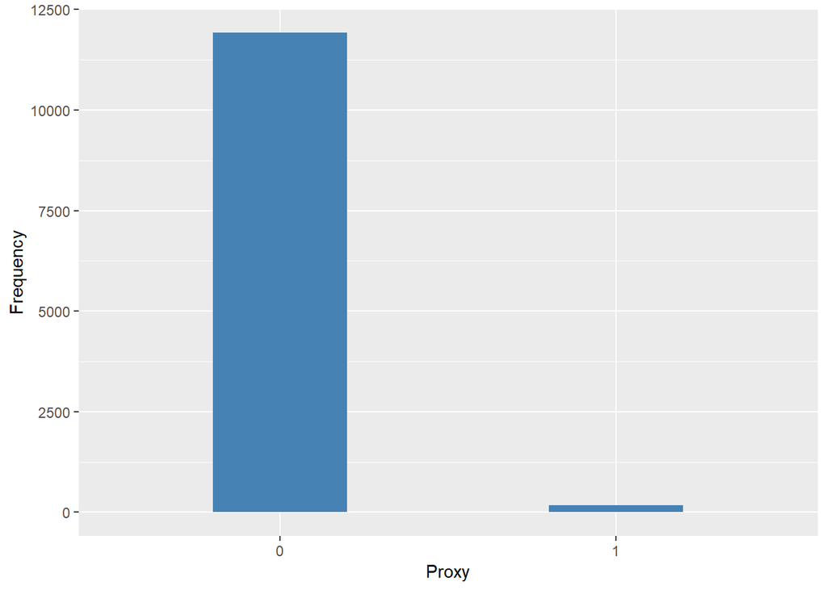

#### 2.1.1.2 Harmonisation algorithm

The harmonized variable is the same than the study-specific variable but the missing values has to be recoded as forllows

- `Na into 999`

**R script:**

```r
ELSA_ds_w1 <- tibble(id = elsa_proxy$id)
ELSA_ds_w1$proxy <- car::recode(elsa_proxy[[2]], "NA=999")
ELSA_ds_w1$proxy <- labelled(ELSA_ds_w1$proxy, labels = cat_label)
label(ELSA_ds_w1$proxy) <- ds_label_all
```

#### 2.1.1.3 Statistical description of the new harmonised variable

Proxy

| Sample size | Missing values |
| --- | --- |
| 12099 | 0 |

Category

|  | 0 | 1 |
| --- | --- | --- |
| Frequency | 11924.00 | 175.00 |
| Percentage | 98.55 | 1.45 |

Type of missing

|  | 991 | 992 | 993 | 994 | 995 | 996 | 997 | 998 | 999 | NA |
| --- | --- | --- | --- | --- | --- | --- | --- | --- | --- | --- |
| Frequency | 0 | 0 | 0 | 0 | 0 | 0 | 0 | 0 | 0 | 0 |
| Percentage | 0 | 0 | 0 | 0 | 0 | 0 | 0 | 0 | 0 | 0 |

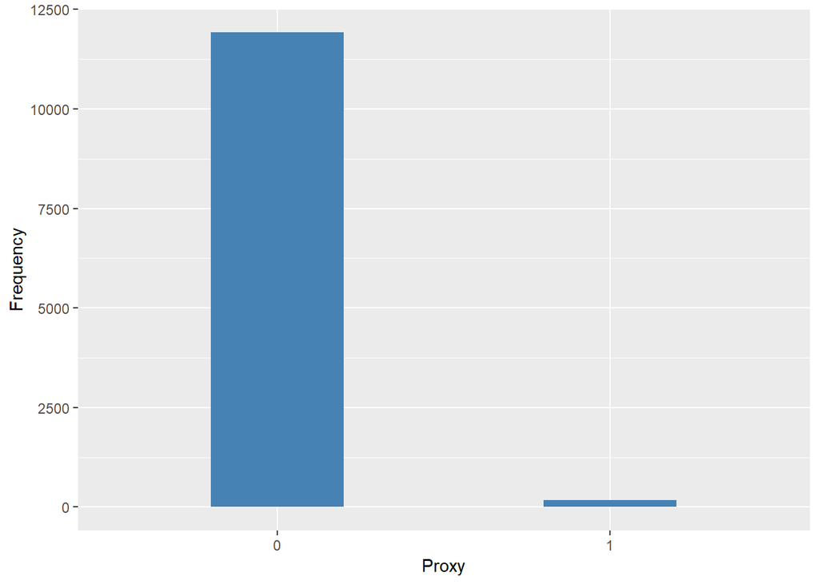

### 2.1.2 Wave 2

#### 2.1.2.1 Study-specific variable description

| **Name** | `proxy` |
| --- | --- |
| **Label** | `proxy respondent` |
| **Table name** | `wave_2_ifs_derived_variables` |
| **Categories** | `0 = No` |
|  | `1 = Yes` |
| **Description** |  |

Proxy

| Sample size | Missing values |
| --- | --- |
| 9432 | 0 |

Category

|  | 0 | 1 |
| --- | --- | --- |
| Frequency | 9307.00 | 125.00 |
| Percentage | 98.67 | 1.33 |

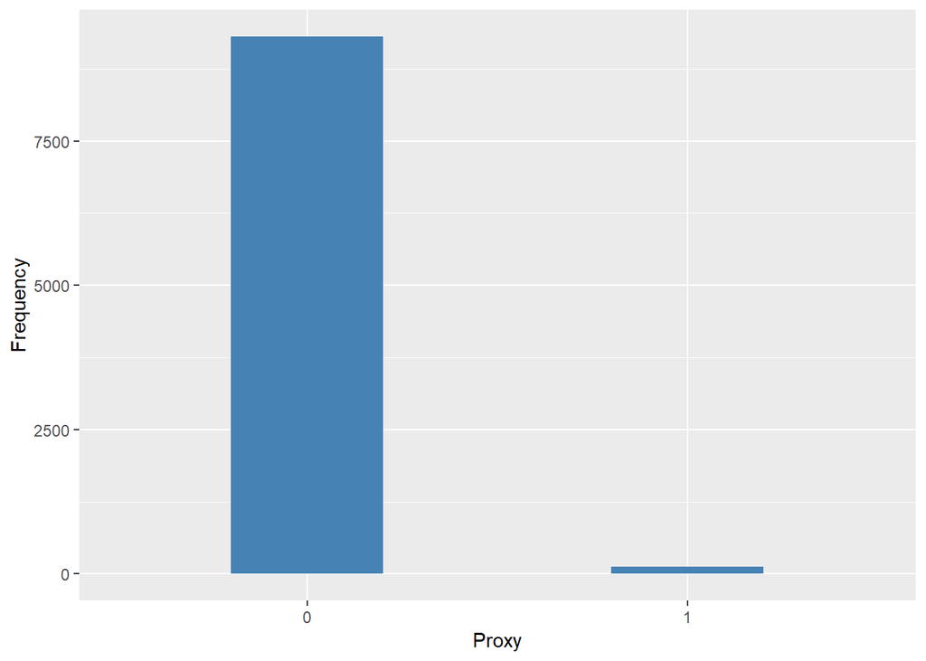

#### 2.1.2.2 Harmonisation algorithm

The harmonized variable is the same than the study-specific variable but the missing values has to be recoded as forllows

- `NA into 999`

**R script:**

```r
ELSA_ds_w2 <- tibble(id = elsa_proxy$id)
ELSA_ds_w2$proxy <- car::recode(elsa_proxy[[2]], "NA=999")
ELSA_ds_w2$proxy <- labelled(ELSA_ds_w2$proxy, labels = cat_label)
label(ELSA_ds_w2$proxy) <- ds_label_all
```

#### 2.1.2.3 Statistical description of the new harmonised variable

Proxy

| Sample size | Missing values |
| --- | --- |
| 9432 | 0 |

Category

|  | 0 | 1 |
| --- | --- | --- |
| Frequency | 9307.00 | 125.00 |
| Percentage | 98.67 | 1.33 |

Type of missing

|  | 991 | 992 | 993 | 994 | 995 | 996 | 997 | 998 | 999 | NA |
| --- | --- | --- | --- | --- | --- | --- | --- | --- | --- | --- |
| Frequency | 0 | 0 | 0 | 0 | 0 | 0 | 0 | 0 | 0 | 0 |
| Percentage | 0 | 0 | 0 | 0 | 0 | 0 | 0 | 0 | 0 | 0 |

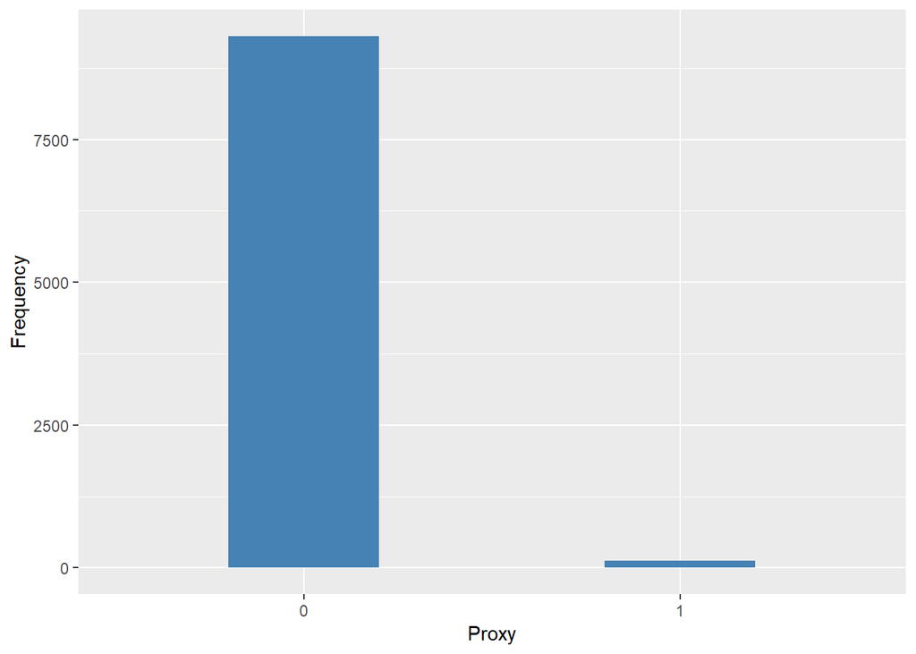

### 2.1.3 Wave 3

#### 2.1.3.1 Study-specific variable description

| **Name** | `proxy` |
| --- | --- |
| **Label** | `proxy respondent` |
| **Table name** | `wave_3_ifs_derived_variables` |
| **Categories** | `0 = No` |
|  | `1 = Yes` |
| **Description** |  |

Proxy

| Sample size | Missing values |
| --- | --- |
| 9771 | 0 |

Category

|  | 0 | 1 |
| --- | --- | --- |
| Frequency | 9539.00 | 232.00 |
| Percentage | 97.63 | 2.37 |

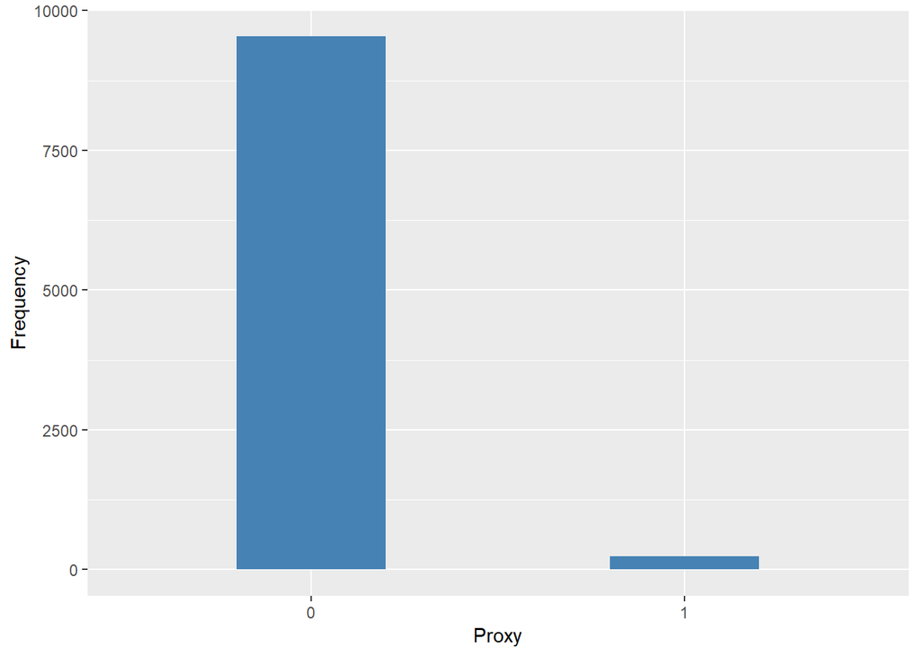

#### 2.1.3.2 Harmonisation algorithm

The harmonized variable is the same than the study-specific variable but the missing values has to be recoded as forllows

- `Na into 999`

**R script:**

```r
ELSA_ds_w3 <- tibble(id = elsa_proxy$id)
ELSA_ds_w3$proxy <- car::recode(elsa_proxy[[2]], "NA=999")
ELSA_ds_w3$proxy <- labelled(ELSA_ds_w3$proxy, labels = cat_label)
label(ELSA_ds_w3$proxy) <- ds_label_all
```

#### 2.1.3.3 Statistical description of the new harmonised variable

Proxy

| Sample size | Missing values |
| --- | --- |
| 9771 | 0 |

Category

|  | 0 | 1 |
| --- | --- | --- |
| Frequency | 9539.00 | 232.00 |
| Percentage | 97.63 | 2.37 |

Type of missing

|  | 991 | 992 | 993 | 994 | 995 | 996 | 997 | 998 | 999 | NA |
| --- | --- | --- | --- | --- | --- | --- | --- | --- | --- | --- |
| Frequency | 0 | 0 | 0 | 0 | 0 | 0 | 0 | 0 | 0 | 0 |
| Percentage | 0 | 0 | 0 | 0 | 0 | 0 | 0 | 0 | 0 | 0 |

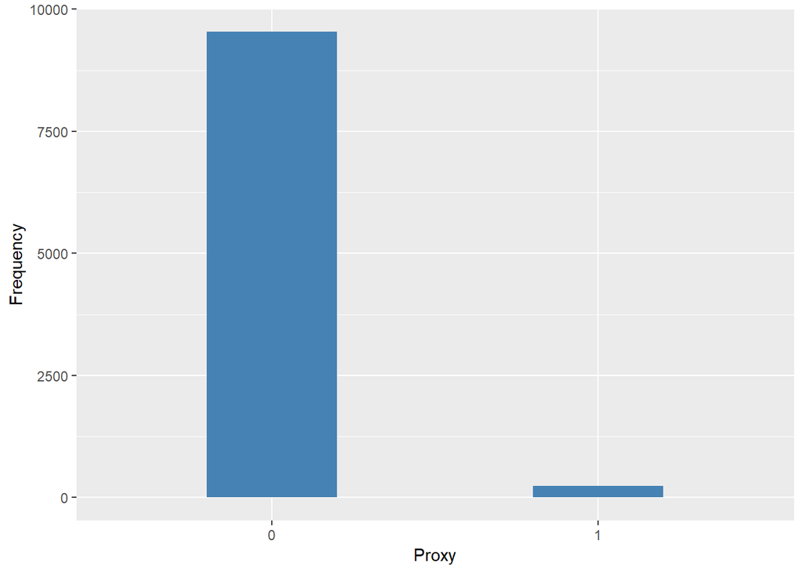

### 2.1.4 Wave 4

#### 2.1.4.1 Study-specific variable description

| **Name** | `proxy` |
| --- | --- |
| **Label** | `proxy respondent` |
| **Table name** | `wave_4_ifs_derived_variables` |
| **Categories** | `0 = No` |
|  | `1 = Yes` |
| **Description** |  |

Proxy

| Sample size | Missing values |
| --- | --- |
| 11050 | 0 |

Category

|  | 0 | 1 |
| --- | --- | --- |
| Frequency | 10604.00 | 446.00 |
| Percentage | 95.96 | 4.04 |

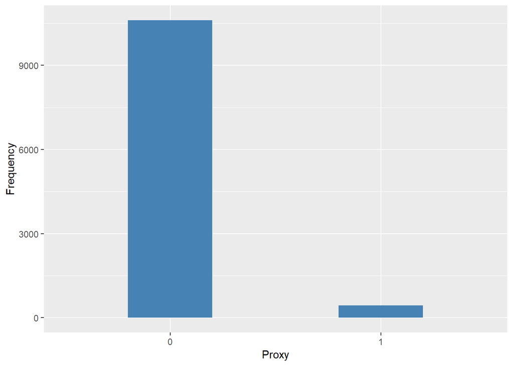

#### 2.1.4.2 Harmonisation algorithm

The harmonized variable is the same than the study-specific variable but the missing values has to be recoded as forllows

- `Na into 999`

**R script:**

```r
ELSA_ds_w4 <- tibble(id = elsa_proxy$id)
ELSA_ds_w4$proxy <- car::recode(elsa_proxy[[2]], "NA=999")
ELSA_ds_w4$proxy <- labelled(ELSA_ds_w4$proxy, labels = cat_label)
label(ELSA_ds_w4$proxy) <- ds_label_all
```

#### 2.1.4.3 Statistical description of the new harmonised variable

Proxy

| Sample size | Missing values |
| --- | --- |
| 11050 | 0 |

Category

|  | 0 | 1 |
| --- | --- | --- |
| Frequency | 10604.00 | 446.00 |
| Percentage | 95.96 | 4.04 |

Type of missing

|  | 991 | 992 | 993 | 994 | 995 | 996 | 997 | 998 | 999 | NA |
| --- | --- | --- | --- | --- | --- | --- | --- | --- | --- | --- |
| Frequency | 0 | 0 | 0 | 0 | 0 | 0 | 0 | 0 | 0 | 0 |
| Percentage | 0 | 0 | 0 | 0 | 0 | 0 | 0 | 0 | 0 | 0 |

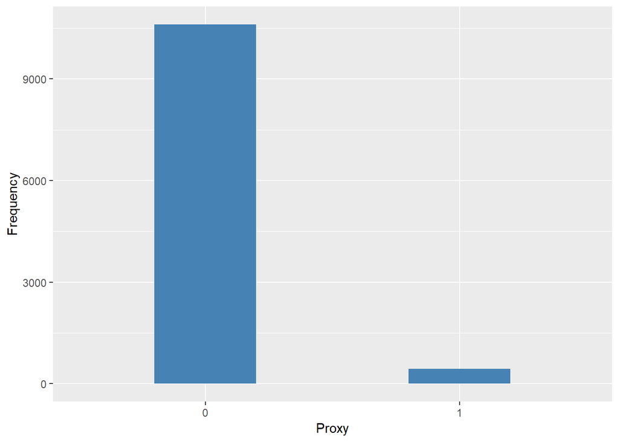

### 2.1.5 Wave 5

#### 2.1.5.1 Study-specific variable description

| **Name** | `proxy` |
| --- | --- |
| **Label** | `proxy respondent` |
| **Table name** | `wave_5_ifs_derived_variables` |
| **Categories** | `0 = No` |
|  | `1 = Yes` |
| **Description** |  |

Proxy

| Sample size | Missing values |
| --- | --- |
| 10274 | 0 |

Category

|  | 0 | 1 |
| --- | --- | --- |
| Frequency | 9737.00 | 537.00 |
| Percentage | 94.77 | 5.23 |

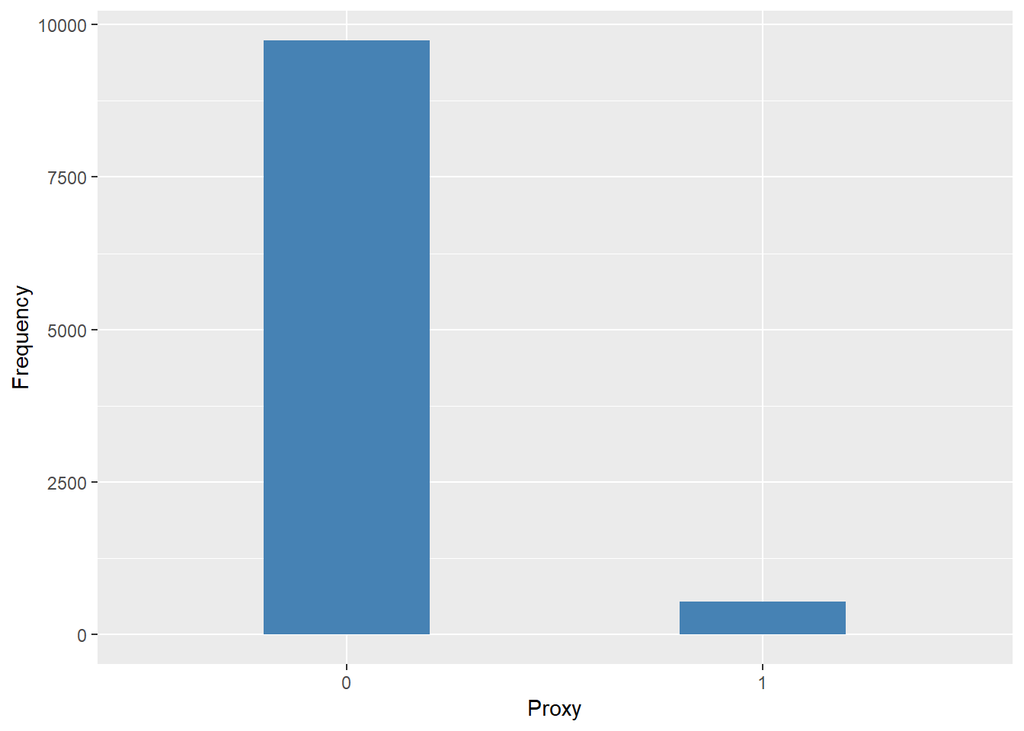

#### 2.1.5.2 Harmonisation algorithm

The harmonized variable is the same than the study-specific variable but the missing values has to be recoded as forllows

- `NA into 999`

**R script:**

```r
ELSA_ds_w5 <- tibble(id = elsa_proxy$id)
ELSA_ds_w5$proxy <- car::recode(elsa_proxy[[2]], "NA=999")
ELSA_ds_w5$proxy <- labelled(ELSA_ds_w5$proxy, labels = cat_label)
label(ELSA_ds_w5$proxy) <- ds_label_all
```

#### 2.1.5.3 Statistical description of the new harmonised variable

Proxy

| Sample size | Missing values |
| --- | --- |
| 10274 | 0 |

Category

|  | 0 | 1 |
| --- | --- | --- |
| Frequency | 9737.00 | 537.00 |
| Percentage | 94.77 | 5.23 |

Type of missing

|  | 991 | 992 | 993 | 994 | 995 | 996 | 997 | 998 | 999 | NA |
| --- | --- | --- | --- | --- | --- | --- | --- | --- | --- | --- |
| Frequency | 0 | 0 | 0 | 0 | 0 | 0 | 0 | 0 | 0 | 0 |
| Percentage | 0 | 0 | 0 | 0 | 0 | 0 | 0 | 0 | 0 | 0 |

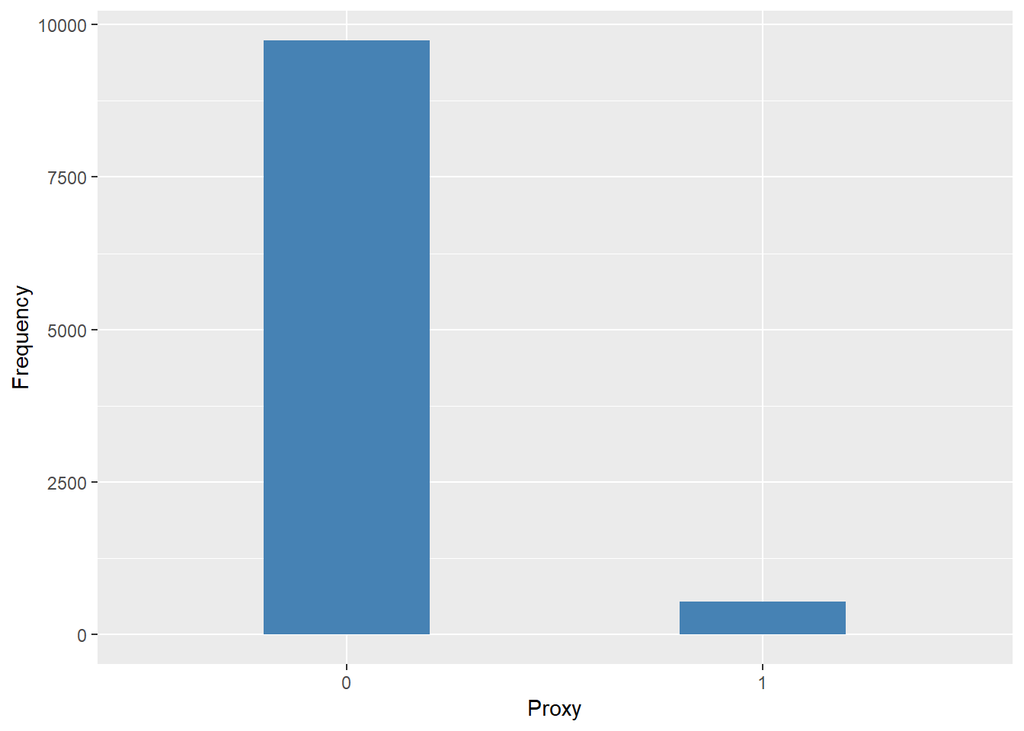

### 2.1.6 Wave 6

#### 2.1.6.1 Study-specific variable description

| **Name** | `proxy` |
| --- | --- |
| **Label** | `proxy respondent` |
| **Table name** | `wave_6_ifs_derived_variables` |
| **Categories** | `0 = No` |
|  | `1 = Yes` |
| **Description** |  |

Proxy

| Sample size | Missing values |
| --- | --- |
| 10601 | 0 |

Category

|  | 0 | 1 |
| --- | --- | --- |
| Frequency | 9987.00 | 614.00 |
| Percentage | 94.21 | 5.79 |

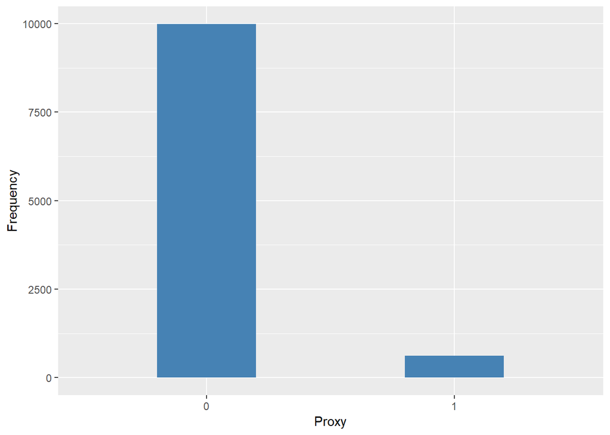

#### 2.1.6.2 Harmonisation algorithm

The harmonized variable is the same than the study-specific variable but the missing values has to be recoded as forllows

- `NA into 999`

**R script:**

```r
ELSA_ds_w6 <- tibble(id = elsa_proxy$id)
ELSA_ds_w6$proxy <- car::recode(elsa_proxy[[2]], "NA=999")
ELSA_ds_w6$proxy <- labelled(ELSA_ds_w6$proxy, labels = cat_label)
label(ELSA_ds_w6$proxy) <- ds_label_all
```

#### 2.1.6.3 Statistical description of the new harmonised variable

Proxy

| Sample size | Missing values |
| --- | --- |
| 10601 | 0 |

Category

|  | 0 | 1 |
| --- | --- | --- |
| Frequency | 9987.00 | 614.00 |
| Percentage | 94.21 | 5.79 |

Type of missing

|  | 991 | 992 | 993 | 994 | 995 | 996 | 997 | 998 | 999 | NA |
| --- | --- | --- | --- | --- | --- | --- | --- | --- | --- | --- |
| Frequency | 0 | 0 | 0 | 0 | 0 | 0 | 0 | 0 | 0 | 0 |
| Percentage | 0 | 0 | 0 | 0 | 0 | 0 | 0 | 0 | 0 | 0 |

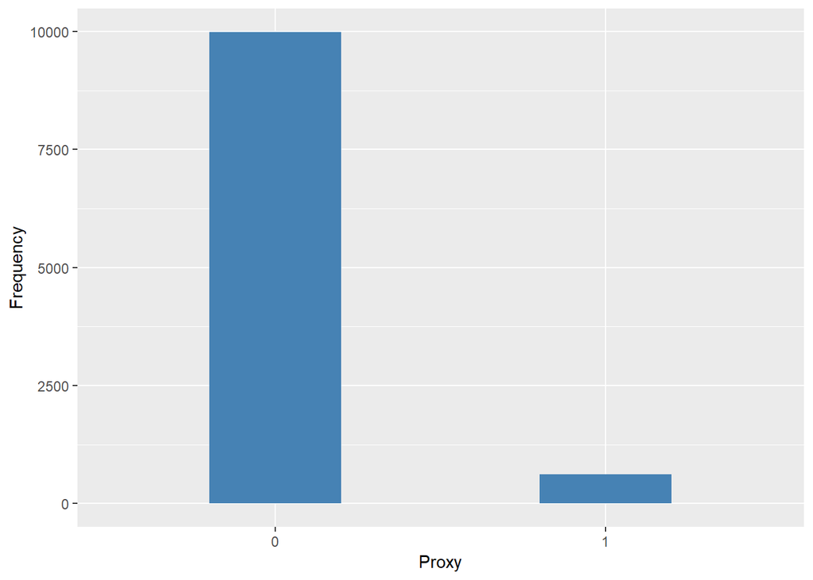

### 2.1.7 Wave 7

| **Name** | `proxy` |
| --- | --- |
| **Label** | `proxy respondent` |
| **Table name** | `wave7_dv` |
| **Categories** | `0 = No` |
|  | `1 = Yes` |
| **Description** |  |

Proxy

| Sample size | Missing values |
| --- | --- |
| 9666 | 0 |

Category

|  | 0 | 1 |
| --- | --- | --- |
| Frequency | 9069.00 | 597.00 |
| Percentage | 93.82 | 6.18 |

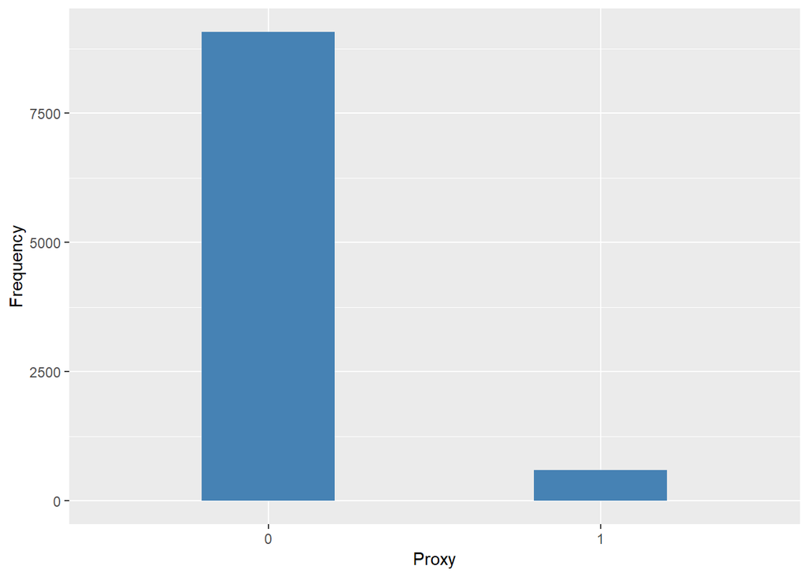

#### 2.1.7.1 Harmonisation algorithm

The harmonized variable is the same than the study-specific variable but the missing values has to be recoded as forllows

- `NA into 999`

**R script:**

```r
ELSA_ds_w7 <- tibble(id = elsa_proxy$id)
ELSA_ds_w7$proxy <- car::recode(elsa_proxy[[2]], "NA=999")
ELSA_ds_w7$proxy <- labelled(ELSA_ds_w7$proxy, labels = cat_label)
label(ELSA_ds_w7$proxy) <- ds_label_all
```

#### 2.1.7.2 Statistical description of the new harmonised variable

Proxy

| Sample size | Missing values |
| --- | --- |
| 9666 | 0 |

Category

|  | 0 | 1 |
| --- | --- | --- |
| Frequency | 9069.00 | 597.00 |
| Percentage | 93.82 | 6.18 |

Type of missing

|  | 991 | 992 | 993 | 994 | 995 | 996 | 997 | 998 | 999 | NA |
| --- | --- | --- | --- | --- | --- | --- | --- | --- | --- | --- |
| Frequency | 0 | 0 | 0 | 0 | 0 | 0 | 0 | 0 | 0 | 0 |
| Percentage | 0 | 0 | 0 | 0 | 0 | 0 | 0 | 0 | 0 | 0 |

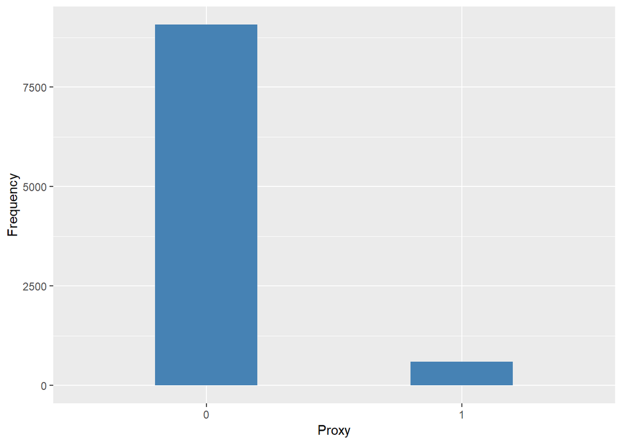

## 2.2 Summary of descriptive statistics of the harmonised variable accross populations and waves

Two tables are generated:

1. Percentages of categories in each harmonised variable.
2. Frequencies and percentages of individuals with different trajectories. To avoid too large table, Only trajectories with percentages larger than 0.3 are shown.

Proxy

| val | label | W1 | W2 | W3 | W4 | W5 | W6 | W7 |
| --- | --- | --- | --- | --- | --- | --- | --- | --- |
| 0 | No | 98.55 | 98.67 | 97.63 | 95.96 | 94.77 | 94.21 | 93.82 |
| 1 | Yes | 1.45 | 1.33 | 2.37 | 4.04 | 5.23 | 5.79 | 6.18 |
| 991 | CAPI interviewer error | 0 | 0 | 0 | 0 | 0 | 0 | 0 |
| 992 | Impute | 0 | 0 | 0 | 0 | 0 | 0 | 0 |
| 993 | Disable to measure | 0 | 0 | 0 | 0 | 0 | 0 | 0 |
| 994 | Not attempt not done | 0 | 0 | 0 | 0 | 0 | 0 | 0 |
| 995 | Does not answer | 0 | 0 | 0 | 0 | 0 | 0 | 0 |
| 996 | Not applicable | 0 | 0 | 0 | 0 | 0 | 0 | 0 |
| 997 | Refuse | 0 | 0 | 0 | 0 | 0 | 0 | 0 |
| 998 | Do not know | 0 | 0 | 0 | 0 | 0 | 0 | 0 |
| 999 | Missing | 0 | 0 | 0 | 0 | 0 | 0 | 0 |
| NA | NA | 0 | 0 | 0 | 0 | 0 | 0 | 0 |
| n | sample size | 12099 | 9432 | 9771 | 11050 | 10274 | 10601 | 9666 |

|  | val | frq | raw.prc |
| --- | --- | --- | --- |
| 1 | 0000000 | 4186 | 22.64 |
| 2 | 0000001 | 70 | 0.38 |
| 3 | 000000NA | 594 | 3.21 |
| 7 | 00000NA0 | 60 | 0.32 |
| 9 | 00000NANA | 424 | 2.29 |
| 17 | 0000NA00 | 55 | 0.30 |
| 25 | 0000NANANA | 549 | 2.97 |
| 41 | 000NA000 | 103 | 0.56 |
| 64 | 000NANANANA | 885 | 4.79 |
| 79 | 00NA0000 | 99 | 0.54 |
| 125 | 00NANANANANA | 1234 | 6.67 |
| 149 | 0NA00000 | 92 | 0.50 |
| 177 | 0NA0NANANANA | 96 | 0.52 |
| 189 | 0NANA0000 | 60 | 0.32 |
| 234 | 0NANANANANANA | 2005 | 10.84 |
| 282 | 1NANANANANANA | 77 | 0.42 |
| 331 | NANA00000 | 809 | 4.38 |
| 333 | NANA0000NA | 105 | 0.57 |
| 339 | NANA000NANA | 78 | 0.42 |
| 354 | NANA00NANANA | 109 | 0.59 |
| 388 | NANA0NANANANA | 295 | 1.60 |
| 412 | NANANA0000 | 1585 | 8.57 |
| 414 | NANANA000NA | 233 | 1.26 |
| 420 | NANANA00NANA | 167 | 0.90 |
| 437 | NANANA0NANANA | 334 | 1.81 |
| 474 | NANANANANA00 | 866 | 4.68 |
| 476 | NANANANANA0NA | 223 | 1.21 |
| 480 | NANANANANANA0 | 451 | 2.44 |
| 481 | NANANANANANA1 | 58 | 0.31 |

# 3 Quality estimation

The derived variables have no levels, they were guessed through the variables from it is computed ‘askpxX’.